# Individual assignment

Bernardo

2023-11-12

# Introduction

In this assignment, we will perform the demand forecast of lettuce for a fast-food chain. The data comes from stores in the US. In order to apply the forecast algorithms we know, firstly we will need to prepare the data, which is spread across several datasets. The first section will be dedicated to the data pre-processing. Then, we will fit an ARIMA model to the data via the Box-Jenkins method, which will be detailed in the second section. Then, we will use Holt-winters’ method to create a second forecast. Finally, we will pick the model that performs better on a test data set and use it to forecast the demand of lettuce for a particular store for the next 14 days.

# Data preparation

First, we import the relevant libraries to the project

```r
library(readr)
library(tidyr)
library(dplyr)
library(forecast)
library(ggplot2)
library(tseries)
```

We start by recognizing the schema of the assignment’s dataset:

```r
# Import the main transactional table, which is "menu_items_all"

main <- read_csv('data/menuitem.csv')

# Columns that are necessary
columns <- c("MD5KEY_ORDERSALE", "StoreNumber", "PLU", "Id", "Quantity")

# Keep only necessary columns
main <- main[,columns]

# Filter for store of interest
main <- filter(main, StoreNumber == 46673)
```

Now we will join that table with the pos_ordersale table to get the date using the “MD5KEY_ORDERSALE” primary key

```r
# Import pos_ordersale table
pos_ordersale <- read_csv("data/pos_ordersale.csv")

main <- left_join(main, select(pos_ordersale, c("date", "MD5KEY_ORDERSALE")), by="MD5KEY_ORDERSALE")
```

Next, we want to bring in the recipe id. To do that, we will need to join the “menu_items” table on “PLU” and “Id” (left) and “RecipeId” (right)

```r
# Import pos_ordersale table
menu_items <- read_csv("data/menu_items.csv")

main <- left_join(main, select(menu_items, c("PLU", "MenuItemId", "RecipeId")), by = c("PLU" = "PLU", "Id" = "MenuItemId"))

main
```

```
## # A tibble: 17,111 × 7
##    MD5KEY_ORDERSALE             StoreNumber    PLU    Id Quantity date  RecipeId
##    <chr>                              <dbl>  <dbl> <dbl>    <dbl> <chr>    <dbl>
##  1 072D3B76BE58E4553A373AF3206…       46673 1.11e8   326        1 15-0…      358
##  2 14811D4F3458058007B0B6908C2…       46673 2.12e8   280        1 15-0…      305
##  3 2B6FD9058A4A28E5E298C95D3C6…       46673 1.21e8    13        1 15-0…       12
##  4 5A3C75477697E093A0B8B81A43A…       46673 2.12e8   280        1 15-0…      305
##  5 1E739D78994A32D295D9C6B6F2D…       46673 1.11e8    12        1 15-0…       10
##  6 07436936F3929B875D312810655…       46673 1.21e8    49        1 15-0…       52
##  7 BD5D0AA9CC8C5768029C5AE0D9A…       46673 1.11e8    48        1 15-0…       50
##  8 43A36CB7B8F291EEF7123CD2A46…       46673 1.21e8    13        1 15-0…       12
##  9 54C0AAC9759B0E3F6D3C6E35B3E…       46673 2.21e8   279        1 15-0…      303
## 10 1E739D78994A32D295D9C6B6F2D…       46673 1.11e8   152        1 15-0…      233
## # ℹ 17,101 more rows
```

Our main transaction table is ready. Now, we need to figure out the quantity of lettuce per recipe. Then, we will be able to group the main table by date and have a total of lettuce demand for each day. Let’s start by identifying the id of lettuce in the dataset

```r
# Import ingredients dataset
ingredients <- read_csv("data/ingredients.csv")

# Grab lettuce's id
filter(ingredients, grepl("Lettuce", IngredientName, ignore.case = TRUE))
```

```
## # A tibble: 2 × 4
##   IngredientName   IngredientShortDescription IngredientId PortionUOMTypeId
##   <chr>            <chr>                             <dbl>            <dbl>
## 1 Lettuce          Lettuce                              27               15
## 2 Lettuce - Metric Lettuce - Metric                    291               13
```

We see that there are two lettuces in the dataset. We know from the live session that the metric lettuce is not used in any of the transactions. Therefore, we will take 27 as the only id for lettuce.

Next, we import the recipes dataset

```r
# Importing recipes dataset
recipes <- read_csv("data/recipes.csv")
```

Then, we know that the ingredients can be used in an item in two ways: Via the ingredients directly or the sub-recipe. We will start by adding the lettuce quantities that come directly from the ingredients table.

```r
# Importing recipe_ingredients

recipe_ingredient_assignments <- read_csv("data/recipe_ingredient_assignments.csv")
# Filter only for lettuce

recipe_ingredient_assignments <- filter(recipe_ingredient_assignments,
                                        IngredientId == 27)

# Join in the recipe table
recipes <- left_join(recipes, select(recipe_ingredient_assignments,
                                   c("RecipeId", "Quantity")),
                    by="RecipeId") %>%
# Mutate to change the NA's to 0
           mutate(Quantity = ifelse(is.na(Quantity), 0, Quantity)) %>%
#Change the name of the column to specify it comes from direct
           rename(quantity_from_direct = Quantity)
```

Now, we need to get the quantity of lettuce from the sub-recipes

```r
# Import sub recipe assignment dataset
recipe_sub_recipe_assignments <- read_csv("data/recipe_sub_recipe_assignments.csv")

# Import the sub_recipes ingredients assignment
sub_recipe_ingr_assignments <- read_csv("data/sub_recipe_ingr_assignments.csv")

# Join the sub_recipes with ingredients to get the recipe id
recipe_sub_recipe_joint <- left_join(sub_recipe_ingr_assignments,
                                     recipe_sub_recipe_assignments,
                                     by='SubRecipeId')

# Filter for lettuce
recipe_sub_recipe_joint <- filter(recipe_sub_recipe_joint,
                                  IngredientId == 27) %>%
                           mutate(total_quantity = Factor*Quantity)

# Group by recipe
recipe_sub_recipe_joint <- recipe_sub_recipe_joint %>%
  group_by(RecipeId) %>%
  summarise(total_quantity = sum(total_quantity, na.rm = TRUE))

# Join with the recipes table
recipes_final <- left_join(recipes, recipe_sub_recipe_joint, by="RecipeId") %>%
# Mutate to change the NA's to 0
           mutate(total_quantity = ifelse(is.na(total_quantity),
                                          0, total_quantity)) %>%
#Change the name of the column to specify it comes from direct
           rename(quantity_from_sub = total_quantity) %>%
#Sum the two columns to get the total of lettuce
           mutate(total_lettuce = quantity_from_direct + quantity_from_sub) %>%
#Filter out recipes that do not have lettuce
           filter(total_lettuce > 0)
```

Then, we join our main transactional table again with this ingredients adjusted table:

```r
# Join the main transactional table with recipes to get the final table
final <- left_join(main, select(recipes_final,
                                     c("RecipeId", "total_lettuce")),
                        by="RecipeId") %>%
# Filter out NA's
              filter(!is.na(total_lettuce)) %>%
# Multiply by total quantity
              mutate(total_lettuce = Quantity*total_lettuce) %>%
# Group by date
              group_by(date) %>%
              summarise(total_lettuce = sum(total_lettuce))
final
```

```
## # A tibble: 103 × 2
##    date     total_lettuce
##    <chr>            <dbl>
##  1 15-03-05           152
##  2 15-03-06           100
##  3 15-03-07            54
##  4 15-03-08           199
##  5 15-03-09           166
##  6 15-03-10           143
##  7 15-03-11           162
##  8 15-03-12           116
##  9 15-03-13           136
## 10 15-03-14            68
## # ℹ 93 more rows
```

The final step is to create a time-series out of it:

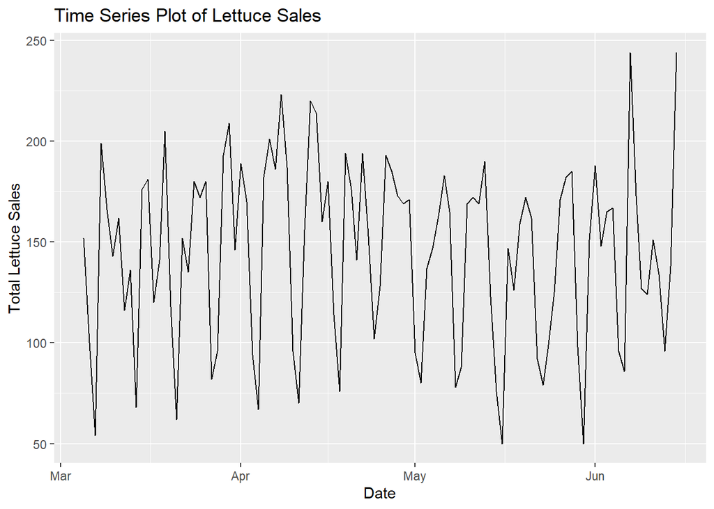

```r
# Transforming date field from the final table
final$date<- as.Date(paste0("20", substr(final$date, 1, 2), "-", substr(final$date, 4, 5), "-", substr(final$date, 7, 8)))

# Build time series
ts <- ts(final, start = min(final$date), frequency = 7)

# Plot the time series directly using ggplot2
ggplot(final, aes(date, total_lettuce)) +
  geom_line() +
  labs(title = "Time Series Plot of Lettuce Sales",
       x = "Date",
       y = "Total Lettuce Sales")
```

# Arima model

Next, we will use the ARIMA model to forecast the demand of lettuce for the next two weeks. An ARIMA model consists of the integration between an autoregressive and moving average models of a time series. The parameters of each of these components are determined by the properties of the time series.

In order to find the best parameters of the ARIMA model, we will apply the *Box-Jenkins* procedure to our dataset. It consists of three steps

1. Identification
2. Estimation
3. Verification

These are detailed next.

## Identification

The first step is to identify if our data is stationary. A stationary time series is such that its statistical properties do not depend on the time at which the series is observed. Therefore, time series with trends or with seasonality are not stationary and we need to remove them before we proceed with the application of the ARIMA model. In order to make a time series stationary we can either rescale the time series or apply differentiation to remove the deterministic components.

We start by making a simple plot of the time series as it is:

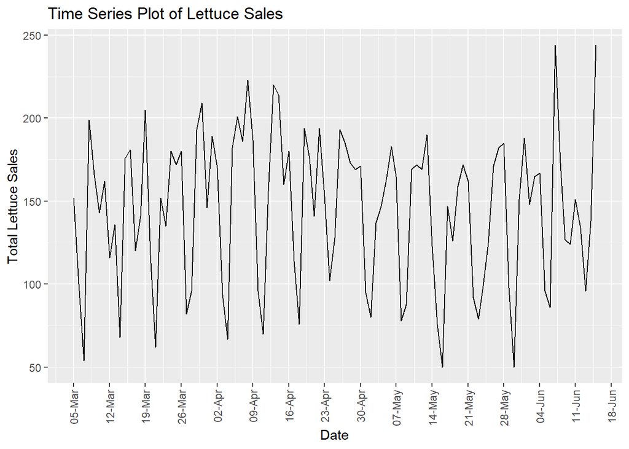

```r
library(scales)

# Plot the time series directly using ggplot2
ggplot(final, aes(date, total_lettuce)) +
  geom_line() +
  labs(title = "Time Series Plot of Lettuce Sales",
       x = "Date",
       y = "Total Lettuce Sales") +
    scale_x_date(labels = date_format("%d-%b"), breaks = date_breaks("7 day")) +
    theme(axis.text.x = element_text(angle = 90, vjust = 0.5, hjust=1))
```

There is no clear indication of trend nor deterministic error. However, there is clear indication of seasonality. We can get a better idea of the individual components of the time series by plotting the decomposition series.

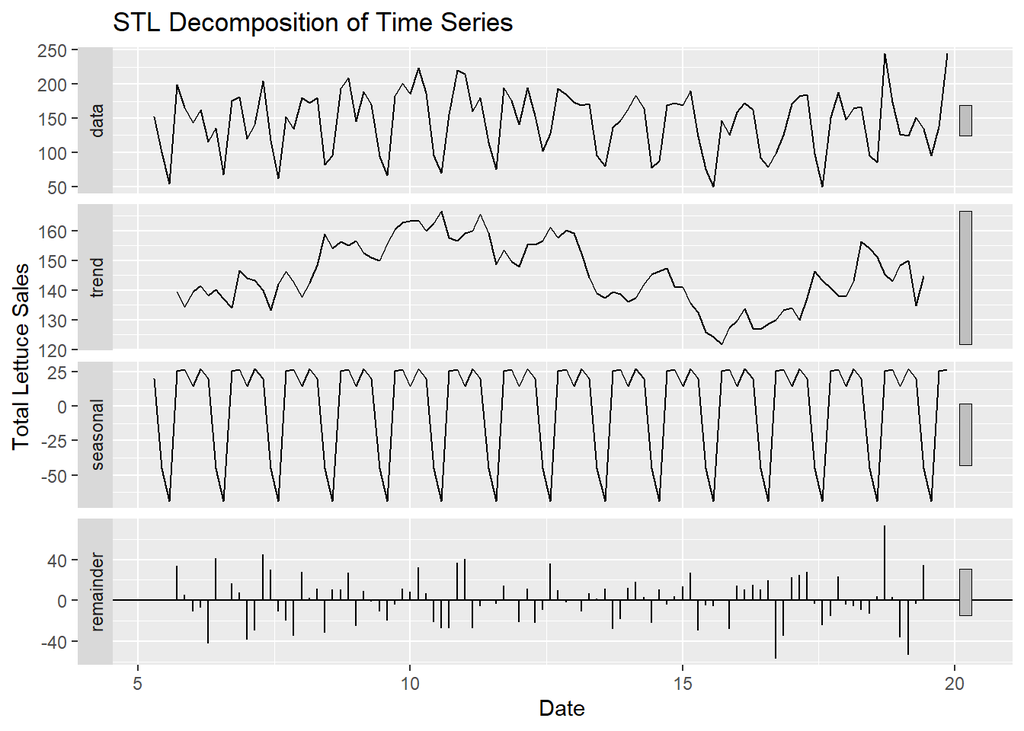

```r
# Transform our df into a time-series object
ar_ts <- ts(final[, 2], frequency=7, start = c(5,3))

# Plot the decomposition of the time-series
stl_result <- decompose(ar_ts)

# Plotting stl
autoplot(stl_result) +
  labs(title = "STL Decomposition of Time Series",
       x = "Date",
       y = "Total Lettuce Sales")
```

As we suspected, there is no strong trend factor, but the size of the grey bar in the seasonal decompositon suggests there is seasonality. Moreover, we can say that the seasonality looks additive, that is, it’s not changing with the period t of the series. We can apply the KPSS test for trend stationary. In this test the null hypothesis is that the time series is level stationary. This means that a large p-value will mean we fail to reject the null and therefore the time series has no trend.

Before we proceed with testing and fitting, it is a good practice to split our data into a training and testing set. This will ensure we will have a good way to compare our forecasts and assess the quality of our parameter choices. We will do a 75%-25% split

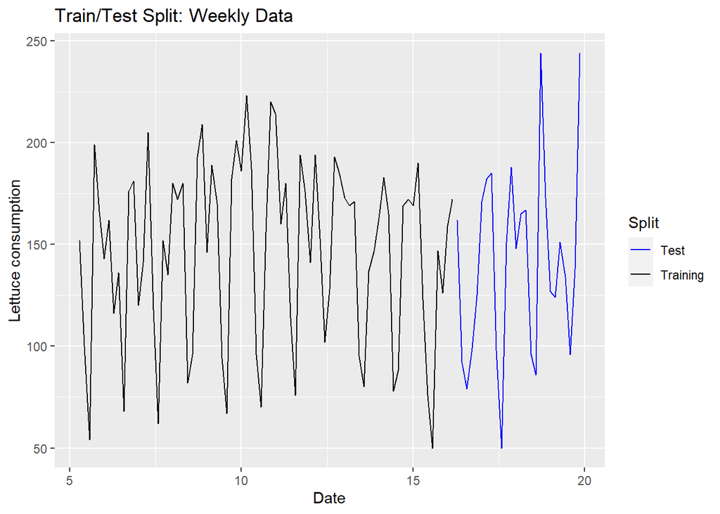

```r
# Splitting the dataset
train_data <- final[final$date <= as.Date('2015/05/20'),]
test_data <- final[final$date > as.Date('2015/05/20'),]

# Time series
train_ts <- ts(train_data[,2], frequency=7, start=c(05,03))
test_ts <- ts(test_data[,2], frequency=7, start=c(16,03))
final_ts <- ts(final[,2], frequency=7, start=c(05,03))

# Plotting the split time series, where the blue line represents the test set
autoplot(train_ts, series="Training") +
  autolayer(test_ts, series="Test") +
  guides(colour=guide_legend("Split")) +
  scale_color_manual(values=c("blue", "black")) +
  xlab("Date") +
  ylab("Lettuce consumption") +
  ggtitle("Train/Test Split: Weekly Data")
```

```r
# Applying KPSS test
kpss.test(train_ts)
```

```
##
##  KPSS Test for Level Stationarity
##
## data:  train_ts
## KPSS Level = 0.10486, Truncation lag parameter = 3, p-value = 0.1
```

The p-value of the test was at least 0.1. So for a 10% confidence level, we fail to reject the hypothesis that the trend is stationary. With this is mind, we don’t perform any first-order differentiation on the time-series.

The next step is to deal with the seasonality factor. To this end, we will use the nsdiffs() function. This will give us the number of seasonal differences required to stationarize the time series, if necessary. We expect this function to return a value greater then 0, since we observe a seasonal trend on the plot.

```r
# Applying KPSS test
nsdiffs(train_ts)
```

```
## [1] 1
```

The result of the function is 1. So we expect our best ARIMA model to have d=0 and D=1. Now we need to determine the p and q parameters of the model. To this end, we will analyse the correlation and partial correlation structures.

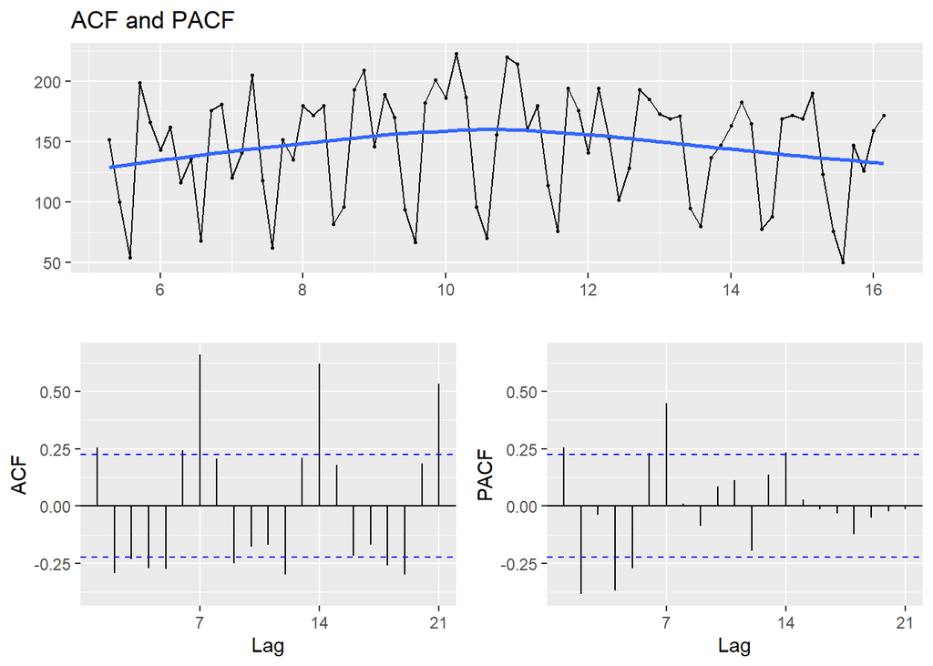

```r
# Applying KPSS test
ggtsdisplay(train_ts,
            plot.type='partial',
            main = 'ACF and PACF',
            smooth=TRUE)
```

The ACF plot shows clearly an autocorrelation at 7 and multiples of 7. This is expected for this dataset, since we expect our data to follow a weekly pattern, so the ACF confirms the seasonal behavior. On the PACF, we see that the plot fades after the lag 7. The following table shows the decision matrix for the ACF and PACF analysis.

|  | AR(p) | MA(q) | ARMA(p,q) |
| --- | --- | --- | --- |
| ACF | Tails off | Cust off after lag q | Tails off |
| PACF | Cust off after lag p | Tails off | Tails off |

Therefore, a seasonal AR model with p = 7 seems to be the best choice.

## Estimation

With this information, we will proceed to use auto.arima() to see if our expectations hold. We will use BIC (Bayes information criteria) as the information criteria parameter.

```r
# Applying the auto.arima function
auto.arima(train_ts, trace = TRUE, ic = 'bic', allowdrift = FALSE)
```

```
##
##  ARIMA(2,0,2)(1,1,1)[7]                    : 683.5968
##  ARIMA(0,0,0)(0,1,0)[7]                    : 689.7027
##  ARIMA(1,0,0)(1,1,0)[7]                    : 676.3963
##  ARIMA(0,0,1)(0,1,1)[7]                    : 670.253
##  ARIMA(0,0,1)(0,1,0)[7]                    : 693.901
##  ARIMA(0,0,1)(1,1,1)[7]                    : 674.4965
##  ARIMA(0,0,1)(0,1,2)[7]                    : 674.4981
##  ARIMA(0,0,1)(1,1,0)[7]                    : 676.365
##  ARIMA(0,0,1)(1,1,2)[7]                    : Inf
##  ARIMA(0,0,0)(0,1,1)[7]                    : 667.8832
##  ARIMA(0,0,0)(1,1,1)[7]                    : 672.0208
##  ARIMA(0,0,0)(0,1,2)[7]                    : 672.0674
##  ARIMA(0,0,0)(1,1,0)[7]                    : 672.7724
##  ARIMA(0,0,0)(1,1,2)[7]                    : Inf
##  ARIMA(1,0,0)(0,1,1)[7]                    : 670.1788
##  ARIMA(1,0,1)(0,1,1)[7]                    : 674.4142
##
##  Best model: ARIMA(0,0,0)(0,1,1)[7]
```

```
## Series: train_ts
## ARIMA(0,0,0)(0,1,1)[7]
##
## Coefficients:
##          sma1
##       -0.7953
## s.e.   0.1941
##
## sigma^2 = 663:  log likelihood = -329.69
## AIC=663.39   AICc=663.57   BIC=667.88
```

The auto.arima() function returned the best model to be ARIMA(0,0,0)(0,1,1)[7]. Recall that the ARIMA model is defined as: ARIMA(p,d,q)(P,D,Q)[s]. This means that p, d and q values refer to the non-seasonal AR. Therefore:

- p = 0 means we need to account for the Y value at 0 lags from a given point t
- d = 0 meains that there is no first-order differentiation needed (level stationary)
- q = 0 means that the model the error term for the MA part should be taken from 0 lagged values
- P = 0 means we don’t need any seasonal auto-regressive numbers
- D = 1 that we need one second order differentiation to remove the seasonality
- Q = 1 refers to the number of seasonal moving average terms.

The next step is to use the Arima function to estimate the models based on the findings from the identification procedure. We take the three best models (i.e: lowest BIC values) in order to compare and validate their performance against the test data.

```r
# Devolping models for the top three models from the auto.arima() function

#ARIMA(0,0,0)(0,1,1)[7]
arima.m1 <- Arima(train_ts, order =c(0,0,0),
                  seasonal = c(0,1,1), include.drift = FALSE)

#ARIMA(1,0,0)(0,1,1)[7]
arima.m2 <- Arima(train_ts, order =c(1,0,0),
                  seasonal = c(0,1,1), include.drift = FALSE)

#ARIMA(0,0,0)(1,1,1)[7]
arima.m3 <- Arima(train_ts, order =c(0,0,1),
                  seasonal = c(0,1,1), include.drift = FALSE)
```

We will use the three models above to forecast, and use the MSE against the test data to select the best performing one

```r
# Devolping models for the top three models from the auto.arima() function

# Forecast for ARIMA(0,0,0)(0,1,1)[7]
arima.f1 <- forecast(arima.m1, h=26)

#Forecast for ARIMA(1,0,0)(0,1,1)[7]
arima.f2 <- forecast(arima.m2, h=26)

#Forecast for ARIMA(0,0,1)(0,1,1)[7]
arima.f3 <- forecast(arima.m3, h=26)
```

```r
# Calculate accuracy for the first model
accuracy(arima.f1, test_ts)
```

```
##                      ME     RMSE      MAE       MPE     MAPE      MASE
## Training set  0.7695725 24.37538 18.09470 -1.904444 13.10255 0.6835559
## Test set     -0.1702936 33.18482 23.92909 -4.234769 17.84490 0.9039592
##                   ACF1 Theil's U
## Training set 0.1720800        NA
## Test set     0.1238206 0.5259847
```

```r
# Calculate accuracy for the second model
accuracy(arima.f2, test_ts)
```

```
##                      ME     RMSE      MAE       MPE     MAPE      MASE
## Training set  0.7372881 23.91650 17.73431 -1.719519 12.77625 0.6699414
## Test set     -0.6818069 33.02373 23.79088 -4.604576 17.79310 0.8987381
##                     ACF1 Theil's U
## Training set 0.004567453        NA
## Test set     0.123746027 0.5269676
```

```r
# Calculate accuracy for the third model
accuracy(arima.f3, test_ts)
```

```
##                      ME     RMSE      MAE       MPE     MAPE      MASE
## Training set  0.7542053 23.93124 17.72511 -1.705640 12.80190 0.6695940
## Test set     -0.6936842 33.02513 23.79584 -4.618957 17.79782 0.8989255
##                    ACF1 Theil's U
## Training set 0.01017734        NA
## Test set     0.12372409 0.5269567
```

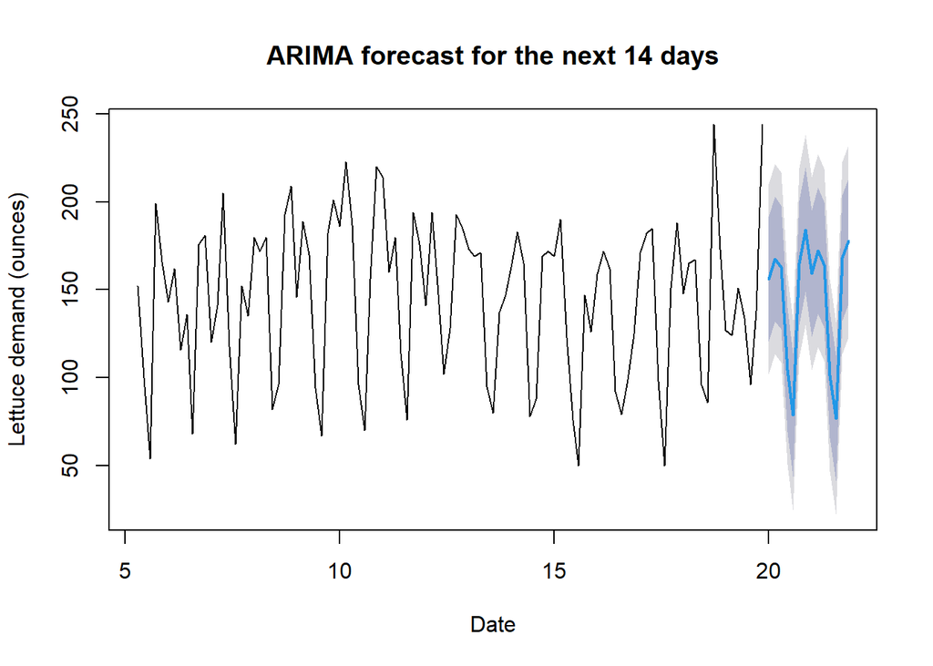

```r
best_arima.m3 <- Arima(final_ts, order=c(0,0,0), seasonal = c(1,1,1))

best_arima.m3.f <- forecast(best_arima.m3, h=14)

plot(best_arima.m3.f, main="ARIMA forecast for the next 14 days", xlab='Date',
     ylab='Lettuce demand (ounces)')
```

## Verification

The final step is to check the validity of our forecast. To this end, we will apply the four proceedures cited below:

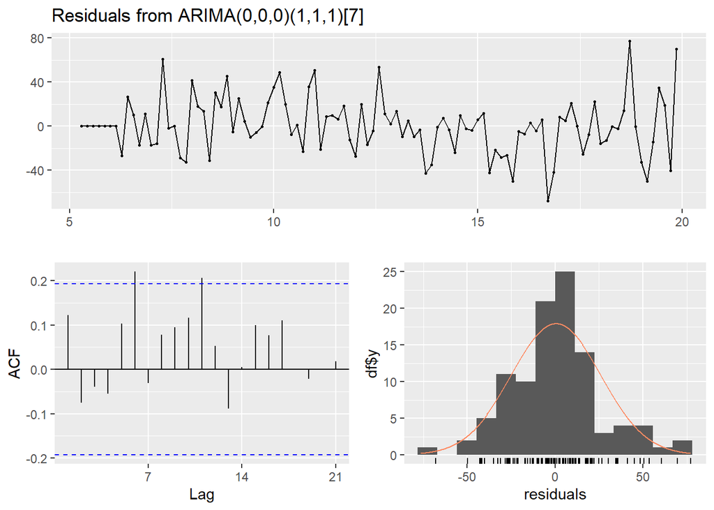

```
##
##  Ljung-Box test
##
## data:  Residuals from ARIMA(0,0,0)(1,1,1)[7]
## Q* = 18.993, df = 12, p-value = 0.08869
##
## Model df: 2.   Total lags used: 14
```

```r
checkresiduals(best_arima.m3)
```

By checking the residuals plot above, we observe that the residuals plot shows no sign of having an average different from zero, and the variance appears to be constant accross the x axis. On the ACF, we see that only two lags fall out of the confidence interval band, which is accepted. Finally, if we check the test results of the Ljung-Box test, the p-value is .088. This means that for a 5% confidence interval we fail to reject the null hypothesis that the data is independently distributed.

# Holt-Winters

For time series analysis, the first step is always to visually inspect the time series. In this regard, the stl() function is quite useful. The arguments of the ets function are the time series and the model to be used. We can pass “ZZZ” as the argument for the model to let the function decide on the best parameters for the training. Let’s go back to the decomposition analysis.

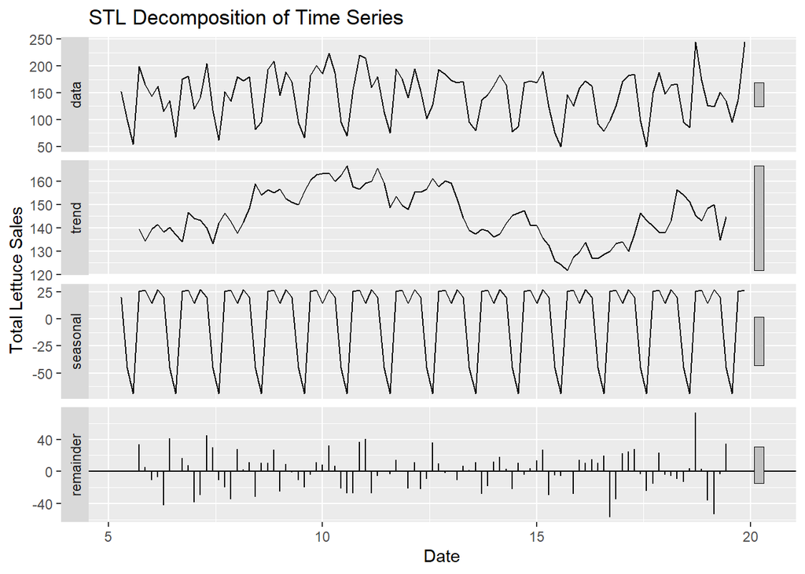

```r
# Plotting stl
autoplot(stl_result) +
  labs(title = "STL Decomposition of Time Series",
       x = "Date",
       y = "Total Lettuce Sales")
```

From this analysis, we could expect the following parameters for the Holt-Winters model:

- Trend: None
- Seasonality: Additive. This is because, although there is clearly seasonality, it does not change pattern depending on the period t.
- Error: Additive, i.e: We don’t see any clear evidence of error changing with the period t.

Next, we run the ets function with the “ZZZ” parameter to see if our expectations are confirmed.

```r
# Fitting the Holt-winters model to the training set
train_ts.ets1 <- ets(train_ts, model = "ZZZ")

# Print the results
train_ts.ets1
```

```
## ETS(A,N,A)
##
## Call:
##  ets(y = train_ts, model = "ZZZ")
##
##   Smoothing parameters:
##     alpha = 0.1107
##     gamma = 1e-04
##
##   Initial states:
##     l = 145.1604
##     s = 30.7463 15.2595 30.6117 25.5871 -70.0768 -48.304
##            16.1763
##
##   sigma:  23.9729
##
##      AIC     AICc      BIC
## 834.1485 837.4818 857.5865
```

It turns out that the ETS returned a model which is aligned with our expectations. Therefore, we won’t train any additional models. Next we again check the residuals of the forecasting model

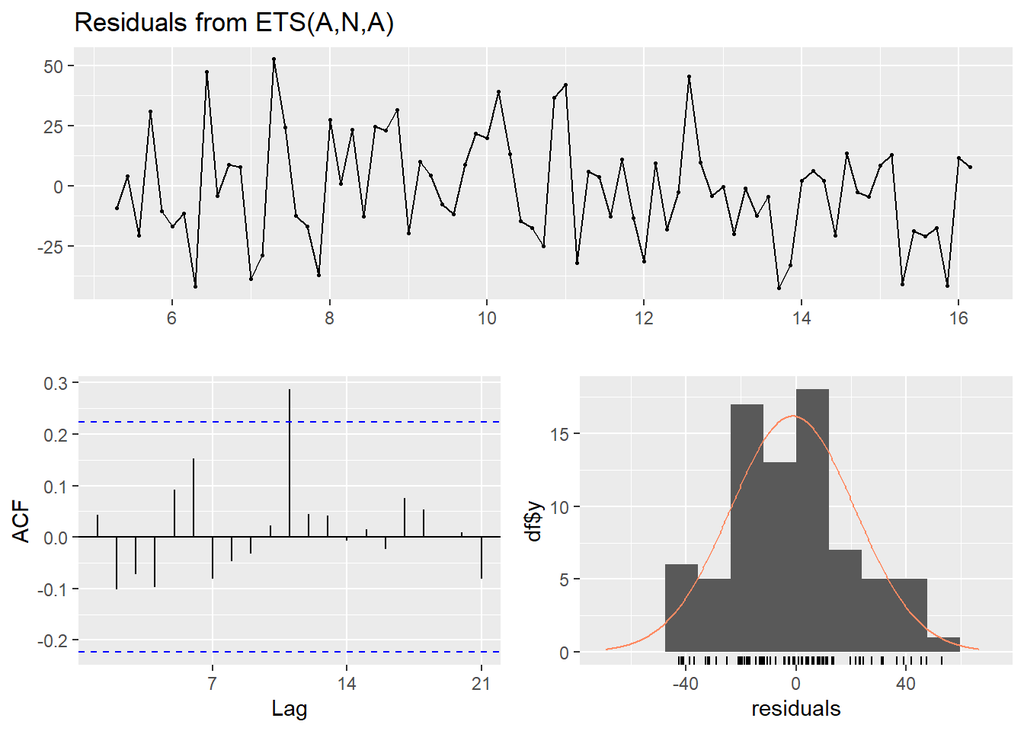

```
##
##  Ljung-Box test
##
## data:  Residuals from ETS(A,N,A)
## Q* = 13.763, df = 14, p-value = 0.4675
##
## Model df: 0.   Total lags used: 14
```

```r
checkresiduals(train_ts.ets1)
```

We see that the residuals plot again seems to be centered around 0 with a constant variance. The ACF plot only shows one point outside of the confidence band, and the distribution of the residuals seems to follow a normal distribution. Finally, we observe that the p-value of the test as 0.4676, which means that we fail to reject the null hypothesis that the residuals distribution is random.

With that, we use the best parameters in the entire dataset and forecast the demand for the next 14 days

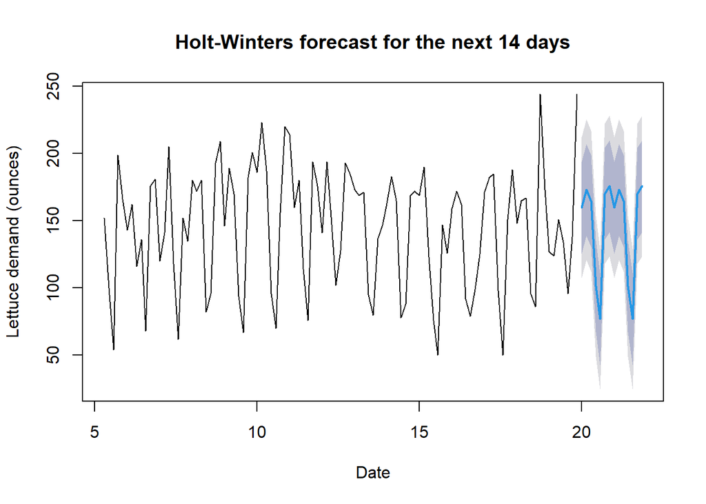

```r
# Train model on the entire data set
final.ets <-  ets(final_ts, model = "ANA")

# Forecast the demand for the next 14 days
final.ets.f <- forecast(final.ets, h=14)

# Plot the forecast
plot(final.ets.f , main="Holt-Winters forecast for the next 14 days", xlab='Date',
     ylab='Lettuce demand (ounces)')
```

```r
print(final.ets)
```

```
## ETS(A,N,A)
##
## Call:
##  ets(y = final_ts, model = "ANA")
##
##   Smoothing parameters:
##     alpha = 1e-04
##     gamma = 1e-04
##
##   Initial states:
##     l = 145.9345
##     s = 27.1516 13.8629 29.8353 24.1902 -69.0184 -44.6583
##            18.6367
##
##   sigma:  26.6343
##
##      AIC     AICc      BIC
## 1164.093 1166.484 1190.440
```

# Models comparison

We compare the Holt-winters model performance against the ARIMA models trained in the previous step:

```r
# Forecast the test set
hw.f1 <- forecast(train_ts.ets1,h=26)

# Determine accuracy against the test set
acc_4 <- accuracy(hw.f1, test_ts)

# Print accuracy
acc_4
```

```
##                     ME     RMSE      MAE       MPE     MAPE      MASE
## Training set -1.267799 22.52837 18.26260 -3.713164 13.84800 0.6898985
## Test set      8.762237 33.27806 25.03077  3.352768 18.42989 0.9455769
##                    ACF1 Theil's U
## Training set 0.04259004        NA
## Test set     0.12506059 0.5175412
```

```r
final_forecast <- data.frame(best_arima.m3.f$mean)
write.csv(final_forecast, "final_forecast.csv")
```